### The following project focus on the analysis of a dataset of Bank Marketing which contains data or information about customers and aims to get useful insights from the data and predict if a new customer will accept a deposit offer or not.

# **Dataset contains Total 17 columns/Features:**

## Output variable (desired target):

### 17 - y - has the client subscribed a term deposit? (binary: yes/no)

```python
conda install -c conda-forge scikit-plot
```

[output not shown]

```python
import numpy as np
import pandas as pd
import matplotlib.pyplot as plt
import seaborn as sns
%matplotlib inline
import warnings
warnings.filterwarnings('ignore')
import graphviz
import pydot
```

### Importing The Datset

```python
df = pd.read_csv('bank.csv')
```

### Exploring the Dataset

```python
df.head()
```

|  | age | job | marital | education | default | balance | housing | loan | contact | day | month | duration | campaign | pdays | previous | poutcome | deposit |
| --- | --- | --- | --- | --- | --- | --- | --- | --- | --- | --- | --- | --- | --- | --- | --- | --- | --- |
| 0 | 59 | admin. | married | secondary | no | 2343 | yes | no | unknown | 5 | may | 1042 | 1 | -1 | 0 | unknown | yes |
| 1 | 56 | admin. | married | secondary | no | 45 | no | no | unknown | 5 | may | 1467 | 1 | -1 | 0 | unknown | yes |
| 2 | 41 | technician | married | secondary | no | 1270 | yes | no | unknown | 5 | may | 1389 | 1 | -1 | 0 | unknown | yes |
| 3 | 55 | services | married | secondary | no | 2476 | yes | no | unknown | 5 | may | 579 | 1 | -1 | 0 | unknown | yes |
| 4 | 54 | admin. | married | tertiary | no | 184 | no | no | unknown | 5 | may | 673 | 2 | -1 | 0 | unknown | yes |

```python
df.shape
```

```
(11162, 17)
```

```python
df.info()
```

```
<class 'pandas.core.frame.DataFrame'>
RangeIndex: 11162 entries, 0 to 11161
Data columns (total 17 columns):
 #   Column     Non-Null Count  Dtype
---  ------     --------------  -----
 0   age        11162 non-null  int64
 1   job        11162 non-null  object
 2   marital    11162 non-null  object
 3   education  11162 non-null  object
 4   default    11162 non-null  object
 5   balance    11162 non-null  int64
 6   housing    11162 non-null  object
 7   loan       11162 non-null  object
 8   contact    11162 non-null  object
 9   day        11162 non-null  int64
 10  month      11162 non-null  object
 11  duration   11162 non-null  int64
 12  campaign   11162 non-null  int64
 13  pdays      11162 non-null  int64
 14  previous   11162 non-null  int64
 15  poutcome   11162 non-null  object
 16  deposit    11162 non-null  object
dtypes: int64(7), object(10)
memory usage: 1.4+ MB
```

# Data Cleaning

```python
df.isnull().values.any()
```

```
False
```

### We have no null values in the dataset

```python
df.duplicated().sum()
```

```
0
```

### We have no duplicate values

### Now we check if there are any suprising values or category in all the 11 categorical features

```python
df.job.value_counts()
```

```
management       2566
blue-collar      1944
technician       1823
admin.           1334
services          923
retired           778
self-employed     405
student           360
unemployed        357
entrepreneur      328
housemaid         274
unknown            70
Name: job, dtype: int64
```

### Job is Categorical Data with 12 categories

```python
df.marital.value_counts()
```

```
married     6351
single      3518
divorced    1293
Name: marital, dtype: int64
```

### Marital Status has a Categorical type with 3 categories

```python
df.education.value_counts()
```

```
secondary    5476
tertiary     3689
primary      1500
unknown       497
Name: education, dtype: int64
```

### Education has a Categorical type with 4 categories

```python
df.default.value_counts()
```

```
no     10994
yes      168
Name: default, dtype: int64
```

### Default has a Categorical type with 2 categories

```python
df.housing.value_counts()
```

```
no     5881
yes    5281
Name: housing, dtype: int64
```

### Housing has a Categorical type with 2 categories

```python
df.loan.value_counts()
```

```
no     9702
yes    1460
Name: loan, dtype: int64
```

```python
df.contact.value_counts()
```

```
cellular     8042
unknown      2346
telephone     774
Name: contact, dtype: int64
```

```python
df.day.unique()
```

```
array([ 5,  6,  7,  8,  9, 12, 13, 14, 15, 16, 19, 20, 21, 23, 26, 27, 28,
       29, 30,  2,  3,  4, 11, 17, 18, 24,  1, 10, 22, 25, 31],
      dtype=int64)
```

```python
df.day.nunique()
```

```
31
```

```python
df.month.value_counts()
```

```
may    2824
aug    1519
jul    1514
jun    1222
nov     943
apr     923
feb     776
oct     392
jan     344
sep     319
mar     276
dec     110
Name: month, dtype: int64
```

```python
df.campaign.unique()
```

```
array([ 1,  2,  3,  4,  6,  5,  8, 11,  9, 10, 15, 12, 14,  7, 24, 13, 17,
       29, 21, 20, 16, 32, 19, 25, 22, 43, 18, 41, 63, 27, 30, 26, 23, 28,
       33, 31], dtype=int64)
```

### No suprising values in loan, contact, day, month and campaign columns here

```python
df.pdays.value_counts()
```

```
-1      8324
 92      106
 182      89
 91       84
 181      81
        ...
 437       1
 728       1
 518       1
 828       1
 118       1
Name: pdays, Length: 472, dtype: int64
```

### It is suprising to see as pdays count to be -1 as it is not possible for days to be -1. When we checked out with the description of the dataset we found that -1 means that the client has never been contacted before.

```python
df.previous.unique()
```

```
array([ 0,  1,  4,  2,  3, 10,  7,  9,  5, 29,  6, 13, 17,  8, 11, 30, 22,
       58, 21, 14, 26, 12, 19, 55, 23, 15, 20, 27, 16, 41, 40, 28, 18, 37],
      dtype=int64)
```

```python
df.poutcome.value_counts()
```

```
unknown    8326
failure    1228
success    1071
other       537
Name: poutcome, dtype: int64
```

### Nothing out of the box in previous and poutcomes columns

```python
df.describe()[['age','balance','duration','campaign','pdays','previous']]
```

|  | age | balance | duration | campaign | pdays | previous |
| --- | --- | --- | --- | --- | --- | --- |
| count | 11162.000000 | 11162.000000 | 11162.000000 | 11162.000000 | 11162.000000 | 11162.000000 |
| mean | 41.231948 | 1528.538524 | 371.993818 | 2.508421 | 51.330407 | 0.832557 |
| std | 11.913369 | 3225.413326 | 347.128386 | 2.722077 | 108.758282 | 2.292007 |
| min | 18.000000 | -6847.000000 | 2.000000 | 1.000000 | -1.000000 | 0.000000 |
| 25% | 32.000000 | 122.000000 | 138.000000 | 1.000000 | -1.000000 | 0.000000 |
| 50% | 39.000000 | 550.000000 | 255.000000 | 2.000000 | -1.000000 | 0.000000 |
| 75% | 49.000000 | 1708.000000 | 496.000000 | 3.000000 | 20.750000 | 1.000000 |
| max | 95.000000 | 81204.000000 | 3881.000000 | 63.000000 | 854.000000 | 58.000000 |

### Here we find that numeric featurees are normal and we find nothing intriguing here!!

```python
df.deposit.value_counts(normalize=True)
```

```
no     0.52616
yes    0.47384
Name: deposit, dtype: float64
```

### So far no ambigious or suprising values have been encountered in the dataset and hence we move forward with EDA

# EDA

### Finding which job type has higher yes/no ratio

#### First we do data visualization to find relationship between the categorical features and the response y

```python
df[df.education=="primary"].deposit.value_counts()
```

```
no     909
yes    591
Name: deposit, dtype: int64
```

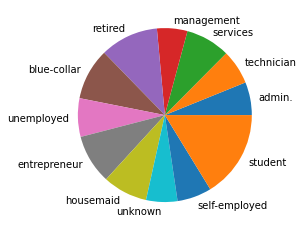

```python
jb = list(df.job.unique())
ratio_job = {}
for x in jb:
    ratio_job[x] = df[df.job==x].deposit.value_counts()[0]/df[df.job==x].deposit.value_counts()[1]
plt.pie(list(ratio_job.values()), labels=list(ratio_job.keys()))
plt.show()
```

### Shows that Students,retired people and unemployed people are more likely to say yes

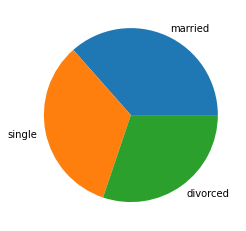

```python
ms = list(df.marital.unique())
ratio_ms = {}
for x in ms:
    ratio_ms[x] = df[df.marital==x].deposit.value_counts()[0]/df[df.marital==x].deposit.value_counts()[1]
plt.pie(list(ratio_ms.values()), labels=list(ratio_ms.keys()))
plt.show()
```

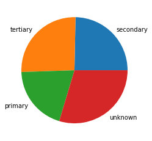

```python
ed = list(df.education.unique())
ratio_ed = {}
for x in ed:
    ratio_ed[x] = df[df.education==x].deposit.value_counts()[1]/df[df.education==x].deposit.value_counts()[0]
plt.pie(list(ratio_ed.values()), labels=list(ratio_ed.keys()))
plt.show()
```

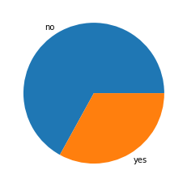

```python
dt = list(df.default.unique())
ratio_dt = {}
for x in dt:
    ratio_dt[x] = df[df.default==x].deposit.value_counts()[1]/df[df.default==x].deposit.value_counts()[0]
plt.pie(list(ratio_dt.values()), labels=list(ratio_dt.keys()))
plt.show()
```

### People with no default are more likely to suscribe to our plans

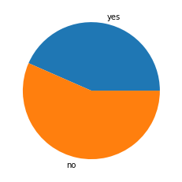

```python
hs = list(df.housing.unique())
ratio_hs = {}
for x in hs:
    ratio_hs[x] = df[df.housing==x].deposit.value_counts()[1]/df[df.housing==x].deposit.value_counts()[0]
plt.pie(list(ratio_hs.values()), labels=list(ratio_hs.keys()))
plt.show()
```

### People who do not have housing loan are more likely to say yes

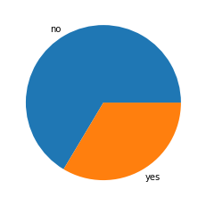

```python
ln = list(df.loan.unique())
ratio_ln = {}
for x in ln:
    ratio_ln[x] = df[df.loan==x].deposit.value_counts()[1]/df[df.loan==x].deposit.value_counts()[0]
plt.pie(list(ratio_ln.values()), labels=list(ratio_ln.keys()))
plt.show()
```

### People who do not have a personal loan are more likely to say yes

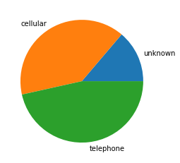

```python
ct = list(df.contact.unique())
ratio_ct = {}
for x in ct:
    ratio_ct[x] = df[df.contact==x].deposit.value_counts()[1]/df[df.contact==x].deposit.value_counts()[0]
plt.pie(list(ratio_ct.values()), labels=list(ratio_ct.keys()))
plt.show()
```

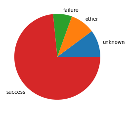

```python
pt = list(df.poutcome.unique())
ratio_pt = {}
for x in pt:
    ratio_pt[x] = df[df.poutcome==x].deposit.value_counts()[0]/df[df.poutcome==x].deposit.value_counts()[1]
plt.pie(list(ratio_pt.values()), labels=list(ratio_pt.keys()))
plt.show()
```

### Clients who said yes to previous marketing campaign are more likely to say yes

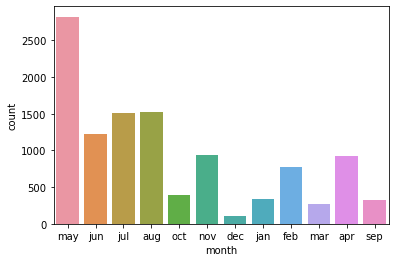

```python
sns.countplot(df.month)
```

### Most calls were made during the month of may and least calls in the month of december

```python
#### Now we do the data visualization for numeric features with the response y
```

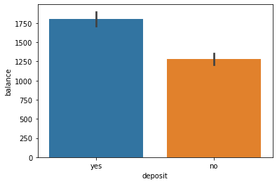

```python
sns.barplot(x="deposit",y="balance",data=df)
```

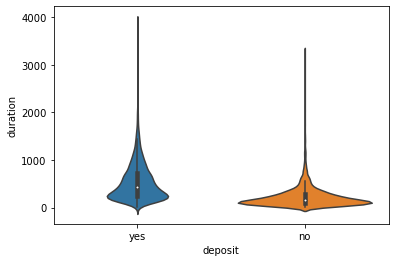

```python
sns.violinplot(x="deposit",y="duration",data=df)
```

### Higher Duration calls led to more yes

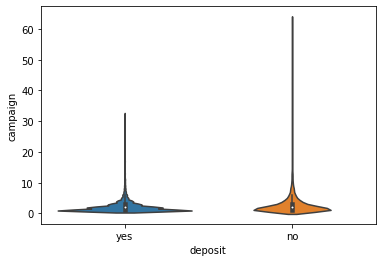

```python
sns.violinplot(x="deposit",y="campaign",data=df)
```

### If campaign days are more than 30 for a client than there is very little chance to say yes

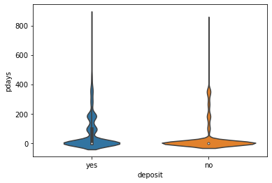

```python
sns.violinplot(x="deposit",y="pdays",data=df)
```

### if pdays are more than greater chance of yes

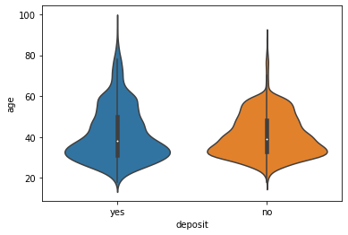

```python
sns.violinplot(x="deposit",y="age",data=df)
```

### Old people above 60 are more likely to say yes

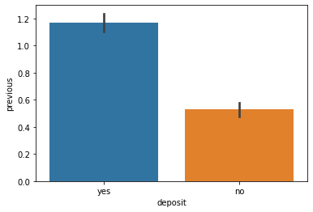

```python
sns.barplot(x="deposit",y="previous",data=df)
```

### If number of contacts performed previously are high then higher the chance of saying yes

## Dealing with Outliers

### We remove outliers from the numeric features that are balance, duration, pdays, campaign and previous

#### We remove all those values from data set which are 3 standard deviation above or below the mean

```python
from scipy import stats
new_df = df
new_df = new_df[(np.abs(stats.zscore(new_df["balance"])) < 3)]
new_df.shape
```

```
(10989, 17)
```

```python
new_df = new_df[(np.abs(stats.zscore(new_df["duration"])) < 3)]
new_df.shape
```

```
(10792, 17)
```

```python
new_df = new_df[(np.abs(stats.zscore(new_df["pdays"])) < 3)]
new_df.shape
```

```
(10624, 17)
```

```python
new_df = new_df[(np.abs(stats.zscore(new_df["campaign"])) < 3)]
new_df.shape
```

```
(10422, 17)
```

```python
new_df = new_df[(np.abs(stats.zscore(new_df["previous"])) < 3)]
new_df.shape
```

```
(10217, 17)
```

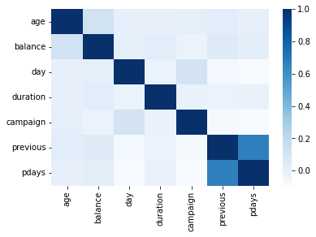

```python
sns.heatmap(new_df[['age', 'balance', 'day', 'duration', 'campaign', 'previous','pdays']].corr(),cmap="Blues")
```

### Above is correlation plot which shows which of the numeric features are correlated with each other. We know that when features are correlated with each other then we have Multi-colinearity Problem. Here the variables previous and pdays are highly correlated with each other. It may be because pdays -1 means peoples are new or involving 1st time in campaign and they have no previous contact so previous ==0. Now as the pdays and previous columns have 80% values as -1 and 0 respectively therefore they are highly correlated with each other.

### Therefore, we drop the column pdays from our dataset.

```python
new_df.drop("pdays",inplace=True,axis=1)
```

```python
new_df.head()
```

|  | age | job | marital | education | default | balance | housing | loan | contact | day | month | duration | campaign | previous | poutcome | deposit |
| --- | --- | --- | --- | --- | --- | --- | --- | --- | --- | --- | --- | --- | --- | --- | --- | --- |
| 0 | 59 | admin. | married | secondary | no | 2343 | yes | no | unknown | 5 | may | 1042 | 1 | 0 | unknown | yes |
| 2 | 41 | technician | married | secondary | no | 1270 | yes | no | unknown | 5 | may | 1389 | 1 | 0 | unknown | yes |
| 3 | 55 | services | married | secondary | no | 2476 | yes | no | unknown | 5 | may | 579 | 1 | 0 | unknown | yes |
| 4 | 54 | admin. | married | tertiary | no | 184 | no | no | unknown | 5 | may | 673 | 2 | 0 | unknown | yes |
| 5 | 42 | management | single | tertiary | no | 0 | yes | yes | unknown | 5 | may | 562 | 2 | 0 | unknown | yes |

```python
new_df.shape
```

```
(10217, 16)
```

## Encoding Categorical Features

```python
from sklearn.preprocessing import LabelEncoder
dic = {"yes":1,"no":0}
lst = ["deposit","loan","default","housing"]
for i in lst:
    new_df[i] = new_df[i].map(dic)
```

### Encoding features 'y', 'loan', 'default' and 'housing' with yes and no as 1 and 0 respectively

```python
lst1=['month',"contact","poutcome","day"]
for i in lst1:
    lec=LabelEncoder()
    new_df[i]=lec.fit_transform(new_df[i].values)
```

```python
new_df = pd.get_dummies(new_df, columns = ['job','marital','education'])
```

```python
new_df
```

|  | age | default | balance | housing | loan | contact | day | month | duration | campaign | ... | job_technician | job_unemployed | job_unknown | marital_divorced | marital_married | marital_single | education_primary | education_secondary | education_tertiary | education_unknown |
| --- | --- | --- | --- | --- | --- | --- | --- | --- | --- | --- | --- | --- | --- | --- | --- | --- | --- | --- | --- | --- | --- |
| 0 | 59 | 0 | 2343 | 1 | 0 | 2 | 4 | 8 | 1042 | 1 | ... | 0 | 0 | 0 | 0 | 1 | 0 | 0 | 1 | 0 | 0 |
| 2 | 41 | 0 | 1270 | 1 | 0 | 2 | 4 | 8 | 1389 | 1 | ... | 1 | 0 | 0 | 0 | 1 | 0 | 0 | 1 | 0 | 0 |
| 3 | 55 | 0 | 2476 | 1 | 0 | 2 | 4 | 8 | 579 | 1 | ... | 0 | 0 | 0 | 0 | 1 | 0 | 0 | 1 | 0 | 0 |
| 4 | 54 | 0 | 184 | 0 | 0 | 2 | 4 | 8 | 673 | 2 | ... | 0 | 0 | 0 | 0 | 1 | 0 | 0 | 0 | 1 | 0 |
| 5 | 42 | 0 | 0 | 1 | 1 | 2 | 4 | 8 | 562 | 2 | ... | 0 | 0 | 0 | 0 | 0 | 1 | 0 | 0 | 1 | 0 |
| ... | ... | ... | ... | ... | ... | ... | ... | ... | ... | ... | ... | ... | ... | ... | ... | ... | ... | ... | ... | ... | ... |
| 11157 | 33 | 0 | 1 | 1 | 0 | 0 | 19 | 0 | 257 | 1 | ... | 0 | 0 | 0 | 0 | 0 | 1 | 1 | 0 | 0 | 0 |
| 11158 | 39 | 0 | 733 | 0 | 0 | 2 | 15 | 6 | 83 | 4 | ... | 0 | 0 | 0 | 0 | 1 | 0 | 0 | 1 | 0 | 0 |
| 11159 | 32 | 0 | 29 | 0 | 0 | 0 | 18 | 1 | 156 | 2 | ... | 1 | 0 | 0 | 0 | 0 | 1 | 0 | 1 | 0 | 0 |
| 11160 | 43 | 0 | 0 | 0 | 1 | 0 | 7 | 8 | 9 | 2 | ... | 1 | 0 | 0 | 0 | 1 | 0 | 0 | 1 | 0 | 0 |
| 11161 | 34 | 0 | 0 | 0 | 0 | 0 | 8 | 5 | 628 | 1 | ... | 1 | 0 | 0 | 0 | 1 | 0 | 0 | 1 | 0 | 0 |

10217 rows × 32 columns

```python
new_df.reset_index(inplace=True)
```

```python
new_df.drop("index",axis=1,inplace=True)
```

## Data Preprocessing

#### Splitting the dataset into train and test

```python
from sklearn.pipeline import make_pipeline
from sklearn.model_selection import train_test_split
from sklearn.model_selection import cross_val_score
from sklearn.model_selection import GridSearchCV
```

```python
X = new_df.drop('deposit',axis=1)
Y = new_df["deposit"]
```

```python
X_train, X_test, Y_train, Y_test = train_test_split(X, Y,stratify=Y,  test_size=0.25,random_state=11)
```

#### Feature Scaling is a technique to standardize the independent features present in the data in a fixed range.

```python
from sklearn.preprocessing import StandardScaler
ss = StandardScaler()
X_train_s = ss.fit_transform(X_train)
X_test_s = ss.transform(X_test)
```

## Model Training and Evaluation

```python
from sklearn.linear_model import LogisticRegression
from sklearn.discriminant_analysis import LinearDiscriminantAnalysis, QuadraticDiscriminantAnalysis
from sklearn.metrics import precision_score
from sklearn import metrics
from sklearn import svm
from sklearn.ensemble import RandomForestClassifier
from sklearn.neighbors import KNeighborsClassifier
from sklearn.naive_bayes import GaussianNB
from sklearn.tree import DecisionTreeClassifier
from sklearn.model_selection import train_test_split
from sklearn.metrics import confusion_matrix,ConfusionMatrixDisplay
from sklearn.metrics import classification_report
from sklearn.preprocessing import StandardScaler
from sklearn.metrics import precision_score,recall_score,f1_score,auc,make_scorer,precision_recall_curve,accuracy_score,confusion_matrix
from sklearn.model_selection import RandomizedSearchCV
from sklearn.preprocessing import LabelBinarizer
from sklearn.neural_network import MLPClassifier
from sklearn import tree
import scikitplot as skplt
```

#### Logistic Regression

```python
lr = LogisticRegression()
lr.fit(X_train,Y_train)
Y_pred_lr = lr.predict(X_test)
```

```python
metrics.accuracy_score(Y_test,Y_pred_lr)
```

```
0.7831702544031311
```

```python
lr.score(X_train,Y_train)
```

```
0.7890890107021665
```

#### Interpretations

```python
random_grid = {'penalty':["l1","l2","elasticnet"],'dual':[True,False],'C':[0.1,0.2,0.5,1,2,3,5]}
lr_random = RandomizedSearchCV(estimator = lr, param_distributions = random_grid, n_iter = 100, cv = 3, verbose=2, random_state=42, n_jobs = -1)
lr_random.fit(X_train,Y_train)
Y_pred_lr_random = lr_random.predict(X_test)
metrics.accuracy_score(Y_test,Y_pred_lr_random)
```

```
Fitting 3 folds for each of 42 candidates, totalling 126 fits
```

```
0.7819960861056752
```

```python
lr_random.score(X_train,Y_train)
```

```
0.7897415818324197
```

```python
lr_random.best_params_
```

```
{'penalty': 'l2', 'dual': False, 'C': 0.5}
```

```python
precision_score(Y_test,Y_pred_lr_random)
```

```
0.7722859664607238
```

```python
recall_score(Y_test,Y_pred_lr_random)
```

```
0.7453151618398637
```

```python
f1_score(Y_test,Y_pred_lr_random)
```

```
0.7585609016038145
```

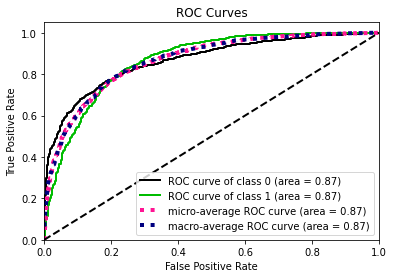

```python
skplt.metrics.plot_roc_curve(Y_test, lr_random.predict_proba(X_test))
plt.show()
```

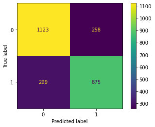

```python
cm = confusion_matrix(Y_test,Y_pred_lr_random, labels=lr_random.classes_)
disp = ConfusionMatrixDisplay(confusion_matrix=cm,display_labels=lr_random.classes_)
disp.plot()
plt.show()
```

#### LDA and QDA

```python
lda = LinearDiscriminantAnalysis()
lda.fit(X_train_s,Y_train)
Y_pred_lda = lda.predict(X_test_s)
```

```python
metrics.accuracy_score(Y_test,Y_pred_lda)
```

```
0.7933463796477495
```

```python
lda.score(X_train_s,Y_train)
```

```
0.798355520751762
```

```python
random_grid = {'solver':["svd",'lsqr','eigen']}
lda_random = RandomizedSearchCV(estimator = lda, param_distributions = random_grid, n_iter = 100, cv = 3, verbose=2, random_state=42, n_jobs = -1,scoring="precision")
lda_random.fit(X_train_s,Y_train)
Y_pred_lda_random = lda_random.predict(X_test_s)
metrics.accuracy_score(Y_test,Y_pred_lda_random)
```

```
Fitting 3 folds for each of 3 candidates, totalling 9 fits
```

```
0.7933463796477495
```

```python
lda_random.score(X_train_s,Y_train)
```

```
0.8091961213637785
```

```python
lda_random.best_params_
```

```
{'solver': 'svd'}
```

```python
precision_score(Y_test,Y_pred_lda_random)
```

```
0.802434456928839
```

```python
recall_score(Y_test,Y_pred_lda_random)
```

```
0.7299829642248722
```

```python
f1_score(Y_test,Y_pred_lda_random)
```

```
0.7644959857270295
```

```python
qda = QuadraticDiscriminantAnalysis()
qda.fit(X_train_s,Y_train)
Y_pred_qda = qda.predict(X_test_s)
```

```python
metrics.accuracy_score(Y_test,Y_pred_qda)
```

```
0.7076320939334638
```

```python
qda.score(X_train_s,Y_train)
```

```
0.7221352127381885
```

```python
random_grid = {'reg_param':[0,0.001,0.002,0.005,0.01,0.05,0.1,0.2,0.3,0.5,0.7,0.9,1,3,5,10]}
qda_random = RandomizedSearchCV(estimator = qda, param_distributions = random_grid, n_iter = 100, cv = 3, verbose=2, random_state=42, n_jobs = -1)
qda_random.fit(X_train_s,Y_train)
Y_pred_qda_random = qda_random.predict(X_test_s)
metrics.accuracy_score(Y_test,Y_pred_qda_random)
```

```
Fitting 3 folds for each of 16 candidates, totalling 48 fits
```

```
0.7506849315068493
```

```python
qda_random.score(X_train_s,Y_train)
```

```
0.7603758809710258
```

```python
qda_random.best_params_
```

```
{'reg_param': 1}
```

```python
precision_score(Y_test,Y_pred_qda_random)
```

```
0.7300771208226221
```

```python
recall_score(Y_test,Y_pred_qda_random)
```

```
0.7257240204429302
```

```python
f1_score(Y_test,Y_pred_qda_random)
```

```
0.72789406236651
```

#### Naive Bayes Classifier

```python
nab = GaussianNB()
nab.fit(X_train_s,Y_train)
Y_pred_nab = nab.predict(X_test_s)
```

```python
metrics.accuracy_score(Y_test,Y_pred_nab)
```

```
0.7185909980430528
```

```python
nab.score(X_train_s,Y_train)
```

```
0.7297050378491255
```

```python
precision_score(Y_test,Y_pred_nab)
```

```
0.7047704770477048
```

```python
recall_score(Y_test,Y_pred_nab)
```

```
0.6669505962521295
```

```python
f1_score(Y_test,Y_pred_nab)
```

```
0.6853391684901533
```

#### Decision Trees

```python
clf = DecisionTreeClassifier()
clf.fit(X_train_s,Y_train)
Y_pred_clf = clf.predict(X_test_s)
```

```python
metrics.accuracy_score(Y_test,Y_pred_clf)
```

```
0.7804305283757339
```

```python
clf.score(X_train_s,Y_train)
```

```
1.0
```

```python
path = clf.cost_complexity_pruning_path(X_train_s, Y_train)
ccp_alphas, impurities = path.ccp_alphas, path.impurities
```

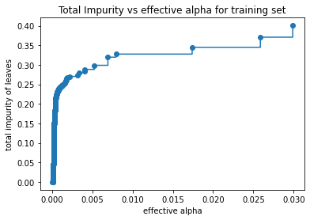

```python
fig, ax = plt.subplots()
ax.plot(ccp_alphas[:-1], impurities[:-1], marker="o", drawstyle="steps-post")
ax.set_xlabel("effective alpha")
ax.set_ylabel("total impurity of leaves")
ax.set_title("Total Impurity vs effective alpha for training set")
```

```python
clfs = []
for ccp_alpha in ccp_alphas:
    clf = DecisionTreeClassifier(random_state=0, ccp_alpha=ccp_alpha)
    clf.fit(X_train_s, Y_train)
    clfs.append(clf)
print(
    "Number of nodes in the last tree is: {} with ccp_alpha: {}".format(
        clfs[-1].tree_.node_count, ccp_alphas[-1]
    )
)
```

```
Number of nodes in the last tree is: 3 with ccp_alpha: 0.09610416037725494
```

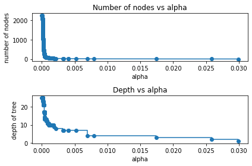

```python
clfs = clfs[:-1]
ccp_alphas = ccp_alphas[:-1]

node_counts = [clf.tree_.node_count for clf in clfs]
depth = [clf.tree_.max_depth for clf in clfs]
fig, ax = plt.subplots(2, 1)
ax[0].plot(ccp_alphas, node_counts, marker="o", drawstyle="steps-post")
ax[0].set_xlabel("alpha")
ax[0].set_ylabel("number of nodes")
ax[0].set_title("Number of nodes vs alpha")
ax[1].plot(ccp_alphas, depth, marker="o", drawstyle="steps-post")
ax[1].set_xlabel("alpha")
ax[1].set_ylabel("depth of tree")
ax[1].set_title("Depth vs alpha")
fig.tight_layout()
```

```python
dtc = DecisionTreeClassifier()
dtc.fit(X_train_s,Y_train)
Y_pred_dtc = dtc.predict(X_test_s)
metrics.accuracy_score(Y_test,Y_pred_dtc)
```

```
0.7800391389432485
```

```python
dtc.score(X_train_s,Y_train)
```

```
1.0
```

```python
random_grid = {'criterion':["gini","entropy","log_loss"],'min_samples_split':[2,6,10],'min_samples_leaf':[1,3,5],'ccp_alpha':[0,0.001,0.002,0.003,0.004,0.01,0.1,0.2,0.3]}
dtc_random = RandomizedSearchCV(estimator = dtc, param_distributions = random_grid, n_iter = 100, cv = 3, verbose=2, random_state=42, n_jobs = -1)
dtc_random.fit(X_train_s,Y_train)
Y_pred_dtc_random = dtc_random.predict(X_test_s)
metrics.accuracy_score(Y_test,Y_pred_dtc_random)
```

```
Fitting 3 folds for each of 100 candidates, totalling 300 fits
```

```
0.8289628180039139
```

```python
dtc_random.score(X_train_s,Y_train)
```

```
0.8411641868963717
```

```python
dtc_random.best_params_
```

```
{'min_samples_split': 2,
 'min_samples_leaf': 3,
 'criterion': 'gini',
 'ccp_alpha': 0.001}
```

```python
precision_score(Y_test,Y_pred_dtc_random)
```

```
0.7917656373713381
```

```python
recall_score(Y_test,Y_pred_dtc_random)
```

```
0.8517887563884157
```

```python
f1_score(Y_test,Y_pred_dtc_random)
```

```
0.8206811653672549
```

```python
dt = DecisionTreeClassifier(ccp_alpha=0.006)
dt.fit(X_train_s,Y_train)
```

```
DecisionTreeClassifier(ccp_alpha=0.006)
```

```python
dot_data = tree.export_graphviz(dt,
                  feature_names=X.columns,
                  class_names=["Yes","No"],
                  filled=True, rounded=True,
                  special_characters=True,
                   out_file=None,
                           )
graph = graphviz.Source(dot_data)
graph
graph.format = "png"
graph.render("tree")
```

[output not shown]

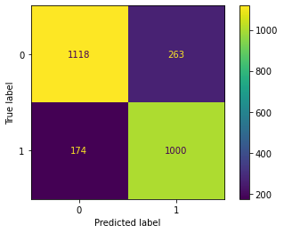

```python
cm = confusion_matrix(Y_test,Y_pred_dtc_random, labels=dtc_random.classes_)
disp = ConfusionMatrixDisplay(confusion_matrix=cm,display_labels=dtc_random.classes_)
disp.plot()
plt.show()
```

#### Bagged Trees

```python
from sklearn.ensemble import BaggingClassifier
```

```python
num_trees = 150
dtc_bag = BaggingClassifier(base_estimator = dtc, n_estimators = num_trees, random_state = 101)
dtc_bag.fit(X_train_s,Y_train)
Y_pred_dtc_bag = dtc_bag.predict(X_test_s)
```

```python
metrics.accuracy_score(Y_test,Y_pred_dtc_bag)
```

```
0.8457925636007828
```

```python
dtc_bag.score(X_train_s,Y_train)
```

```
1.0
```

```python
random_grid = {'n_estimators':[90,110,130,150,175,200,250,300,400]}
dtc_bag_random = RandomizedSearchCV(estimator = dtc_bag, param_distributions = random_grid, n_iter = 100, cv = 3, verbose=2, random_state=42, n_jobs = -1)
dtc_bag_random.fit(X_train_s,Y_train)
Y_pred_dtc_bag_random = dtc_bag_random.predict(X_test_s)
metrics.accuracy_score(Y_test,Y_pred_dtc_bag_random)
```

```
Fitting 3 folds for each of 9 candidates, totalling 27 fits
```

```
0.8426614481409002
```

```python
dtc_bag_random.score(X_train_s,Y_train)
```

```
1.0
```

```python
dtc_bag_random.best_params_
```

```
{'n_estimators': 90}
```

```python
precision_score(Y_test,Y_pred_dtc_bag_random)
```

```
0.8128038897893031
```

```python
recall_score(Y_test,Y_pred_dtc_bag_random)
```

```
0.854344122657581
```

```python
f1_score(Y_test,Y_pred_dtc_bag_random)
```

```
0.8330564784053156
```

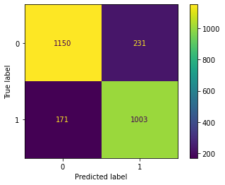

```python
cm = confusion_matrix(Y_test,Y_pred_dtc_bag_random, labels=dtc_bag_random.classes_)
disp = ConfusionMatrixDisplay(confusion_matrix=cm,display_labels=dtc_bag_random.classes_)
disp.plot()
plt.show()
```

#### Random Forest

```python
rf = RandomForestClassifier()
rf.fit(X_train_s,Y_train)
Y_pred_rf = rf.predict(X_test_s)
```

```python
metrics.accuracy_score(Y_test,Y_pred_rf)
```

```
0.8320939334637965
```

```python
rf.score(X_train_s,Y_train)
```

```
1.0
```

```python
random_grid = {'criterion':["gini","entropy","log_loss"],'min_samples_split':[2,6,10],'min_samples_leaf':[1,3,5],'n_estimators':[1,10,30,50,70,90,110,130,150,175,200,250,300,400],"max_features":['sqrt','log2']}
rf_random = RandomizedSearchCV(estimator = rf, param_distributions = random_grid, n_iter = 100, cv = 3, verbose=2, random_state=42, n_jobs = -1)
rf_random.fit(X_train_s,Y_train)
Y_pred_rf_random = rf_random.predict(X_test_s)
metrics.accuracy_score(Y_test,Y_pred_rf_random)
```

```
Fitting 3 folds for each of 100 candidates, totalling 300 fits
```

```
0.8352250489236791
```

```python
rf_random.score(X_train_s,Y_train)
```

```
0.9249543200208823
```

```python
rf_random.best_params_
```

```
{'n_estimators': 300,
 'min_samples_split': 2,
 'min_samples_leaf': 3,
 'max_features': 'sqrt',
 'criterion': 'gini'}
```

```python
precision_score(Y_test,Y_pred_rf_random)
```

```
0.8073469387755102
```

```python
recall_score(Y_test,Y_pred_rf_random)
```

```
0.8424190800681431
```

```python
f1_score(Y_test,Y_pred_rf_random)
```

```
0.8245102125885786
```

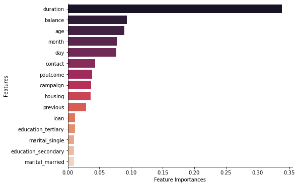

```python
plt.figure(figsize=(8,6))
importances= rf.feature_importances_
feature_importances= pd.Series(importances, index=X_train.columns).sort_values(ascending=False)
sns.barplot(x=feature_importances[:15], y=feature_importances.index[:15], palette="rocket")
sns.despine()
plt.xlabel("Feature Importances")
plt.ylabel("Features")
plt.show()
```

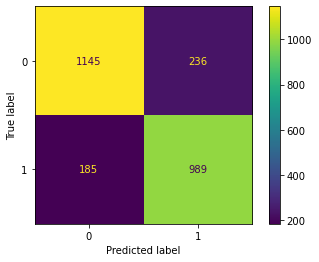

```python
cm = confusion_matrix(Y_test,Y_pred_rf_random, labels=rf_random.classes_)
disp = ConfusionMatrixDisplay(confusion_matrix=cm,display_labels=rf_random.classes_)
disp.plot()
plt.show()
```

#### SVM

```python
sv = svm.SVC()
sv.fit(X_train_s,Y_train)
Y_pred_sv = sv.predict(X_test_s)
```

```python
metrics.accuracy_score(Y_test,Y_pred_sv)
```

```
0.8058708414872798
```

```python
sv.score(X_train_s,Y_train)
```

```
0.8433829287392326
```

#### Now we use cross-validation to hypertune the parameters.

```python
random_grid = {'C':[0.01,0.1,0.5,1,3,5],'kernel':['poly','rbf','sigmoid'],'degree':[3,5]}
sv_random = RandomizedSearchCV(estimator = sv, param_distributions = random_grid, n_iter = 100, cv = 3, verbose=2, random_state=42, n_jobs = -1)
sv_random.fit(X_train_s,Y_train)
Y_pred_sv_random = sv_random.predict(X_test_s)
metrics.accuracy_score(Y_test,Y_pred_sv_random)
```

```
Fitting 3 folds for each of 36 candidates, totalling 108 fits
```

```
0.8058708414872798
```

```python
sv_random.score(X_train_s,Y_train)
```

```
0.8433829287392326
```

```python
sv_random.best_params_
```

```
{'kernel': 'rbf', 'degree': 3, 'C': 1}
```

```python
precision_score(Y_test,Y_pred_sv_random)
```

```
0.7922413793103448
```

```python
recall_score(Y_test,Y_pred_sv_random)
```

```
0.782793867120954
```

```python
f1_score(Y_test,Y_pred_sv_random)
```

```
0.7874892887746359
```

```python
lst_sv = [0.01,0.05,0.1,0.5,1,2,5,10]
accu_sv = []
for i in lst_sv:
    sv = svm.SVC(C=i)
    sv.fit(X_train_s,Y_train)
    Y_pred_sv = sv.predict(X_test_s)
    accu_sv.append(metrics.accuracy_score(Y_test,Y_pred_sv))
```

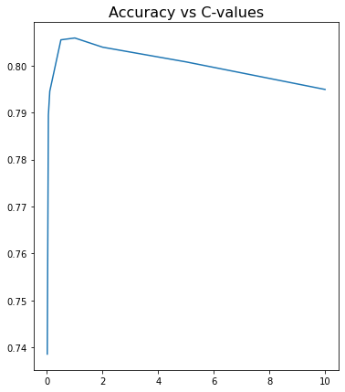

```python
plt.figure(figsize=(6,7))
plt.title("Accuracy vs C-values",fontsize=16)
plt.plot(lst_sv,accu_sv)
```

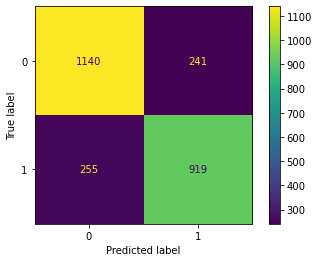

```python
cm = confusion_matrix(Y_test,Y_pred_sv_random, labels=sv_random.classes_)
disp = ConfusionMatrixDisplay(confusion_matrix=cm,display_labels=sv_random.classes_)
disp.plot()
plt.show()
```

#### The rbf kernel with degree as 3 and the cost parameter C as 1 after doing Cross-validation.

#### KNN

```python
knn= KNeighborsClassifier(n_neighbors=5)
knn.fit(X_train_s,Y_train)
Y_pred_knn = knn.predict(X_test_s)
```

```python
metrics.accuracy_score(Y_test,Y_pred_knn)
```

```
0.7342465753424657
```

```python
knn.score(X_train_s,Y_train)
```

```
0.8245888801879405
```

```python
random_grid = {'n_neighbors':[1,3,5,7,10,15,20,50,100,200],'weights':['uniform','distance'],'algorithm':['auto','ball_tree','kd_tree','brute']}
knn_random = RandomizedSearchCV(estimator = knn, param_distributions = random_grid, n_iter = 100, cv = 3, verbose=2, random_state=42, n_jobs = -1)
knn_random.fit(X_train_s,Y_train)
Y_pred_knn_random = knn_random.predict(X_test_s)
metrics.accuracy_score(Y_test,Y_pred_knn_random)
```

```
Fitting 3 folds for each of 80 candidates, totalling 240 fits
```

```
0.7483365949119374
```

```python
knn_random.score(X_train_s,Y_train)
```

```
1.0
```

```python
knn_random.best_params_
```

```
{'weights': 'distance', 'n_neighbors': 15, 'algorithm': 'auto'}
```

```python
precision_score(Y_test,Y_pred_knn_random)
```

```
0.7545541706615532
```

```python
recall_score(Y_test,Y_pred_knn_random)
```

```
0.6703577512776832
```

```python
f1_score(Y_test,Y_pred_knn_random)
```

```
0.7099684258006316
```

```python
lst_k = np.arange(1,50,1)
accu_k = []
for i in lst_k:
    knn= KNeighborsClassifier(n_neighbors=i)
    knn.fit(X_train_s,Y_train)
    Y_pred_knn = knn.predict(X_test_s)
    accu_k.append(metrics.accuracy_score(Y_test,Y_pred_knn))
```

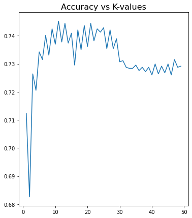

```python
plt.figure(figsize=(6,7))
plt.title("Accuracy vs K-values",fontsize=16)
plt.plot(lst_k,accu_k)
```

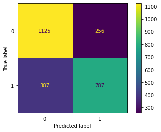

```python
cm = confusion_matrix(Y_test,Y_pred_knn_random, labels=knn_random.classes_)
disp = ConfusionMatrixDisplay(confusion_matrix=cm,display_labels=knn_random.classes_)
disp.plot()
plt.show()
```

#### Neural Networks

```python
nn = MLPClassifier()
nn.fit(X_train_s,Y_train)
Y_pred_nn = knn.predict(X_test_s)
```

```python
nn.score(X_train_s,Y_train)
```

```
0.8860610806577917
```

```python
metrics.accuracy_score(Y_test,Y_pred_nn)
```

```
0.7291585127201565
```

```python
random_grid = {'activation':["logistic"],'alpha':[0.0001,0.0002,0.0005,0.001,0.005,0.01,0.1,1],'learning_rate_init':[0.001,0.002,0.005,0.01,0.02,0.05,0.1,1],'hidden_layer_sizes':[(10,6),(10,7,4),(10,10,10)]}
nn_random = RandomizedSearchCV(estimator = nn, param_distributions = random_grid, n_iter = 100, cv = 3, verbose=2, random_state=42, n_jobs = -1)
nn_random.fit(X_train_s,Y_train)
Y_pred_nn_random = nn_random.predict(X_test_s)
metrics.accuracy_score(Y_test,Y_pred_nn_random)
```

```
Fitting 3 folds for each of 100 candidates, totalling 300 fits
```

```
0.8054794520547945
```

```python
nn_random.best_params_
```

```
{'learning_rate_init': 0.001,
 'hidden_layer_sizes': (10, 7, 4),
 'alpha': 0.0002,
 'activation': 'logistic'}
```

```python
nn_random.score(X_train_s,Y_train)
```

```
0.823675280605586
```

```python
precision_score(Y_test,Y_pred_nn_random)
```

```
0.7697211155378486
```

```python
recall_score(Y_test,Y_pred_nn_random)
```

```
0.8228279386712095
```

```python
f1_score(Y_test,Y_pred_nn_random)
```

```
0.7953890489913545
```

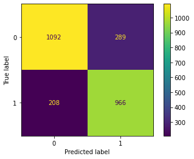

```python
cm = confusion_matrix(Y_test,Y_pred_nn_random, labels=nn_random.classes_)
disp = ConfusionMatrixDisplay(confusion_matrix=cm,display_labels=nn_random.classes_)
disp.plot()
plt.show()
```